# Micobial Analysis PART 2

- Following analysis mainly used the phyloseq project following: https://yanhui09.github.io/microbiome_analysis/1_microbiome_r.html
- All QWIIME output files can be found in folder “/Raw Data/QIIME”

## Loading the required packages

```r
library(phyloseq)
library(vegan)
library(ggplot2)
library(tidyverse)
library("readxl")
library("tibble")
library(picante)
library(devtools)
library(ALDEx2)
library(HMP)
library("rms")
library("gridExtra")
library(readr)
library(stats)
library(ggpubr)
library(purrr)
library(rsample)
library("otuSummary")
library(microbiomeutilities)
library(microbiome)
library(data.table)
library(ape)
library(nlme)
library(RColorBrewer)
library(reshape2)
library(microViz)
library(ANCOMBC)
library(ALDEx2)
library(pairwiseAdonis)
```

```r
# Merging data and building phyloseq project
otumat <- as.matrix(Table)  # This is the un-feature-table.tsv file
TAX = tax_table(as.matrix(Taxa))  # This is the taxonomy.tsv file
tree <-read.tree("tree.nwk")
OTU= otu_table(otumat, taxa_are_rows = TRUE)
TAX= tax_table(TAX) #Taxa_clean_matched file
samples = sample_data(Metadata) #UVM-Metadata
ps <- phyloseq(OTU,TAX,samples,tree)
```

```r
nsamples(ps)       # number of samples
```

```
[1] 176
```

```r
ntaxa(ps)          # number of taxa (OTUs) #7975
```

```
[1] 7975
```

```r
sample_variables(ps) # metadata variables
```

```
[1] "location"  "Room.Type" "Time"
```

### Data Transformation

Total Sum method are used here

```r
#Transformed the phyloseq object that is at species level before collapsing
ps.transformed= transform_sample_counts(ps, function(x) x / sum(x) )
```

### Quality Control

Singleton, doubleton, mitochondria and chloroplast have already been removed in QIIME2 Here we remove 0.1% ASV

```r
ps.transformed_f0.1<- prune_taxa(taxa_sums(ps.transformed)>0.001, ps.transformed) #
ntaxa(ps.transformed_f0.1)#number of taxa after removing 0.1% ASV
```

```
[1] 5092
```

## Alpha Diversity: Shannon Index calculation

Alpha diversity is calculated with **Shannon Index** using using the vegan package

```r
otu2 <- otu_table(ps.transformed_f0.1)
shannon <- diversity(otu2, index="shannon")
write.csv(shannon,"shannon_index") # This file is used for statistical analysis
```

## Beta-Diversity Analysis

Analysis are performed at the genus level

```r
ps.tf0.1_genus <- phyloseq::tax_glom(ps.transformed_f0.1, "Genus", NArm = TRUE)
ntaxa(ps.tf0.1_genus) #623 Genus
```

```
[1] 623
```

*Environmental samples Only*

```r
#####Environmental Data only
ps2.tf0.1_genus_nb <- subset_samples(ps.tf0.1_genus, location != "Saliva" & location != "Palm" & location != "Inside-Blind")
```

*Separating based on Time*

```r
Envir_T0_nb=subset_samples(ps2.tf0.1_genus_nb, Time=="T0")
Envir_T1_nb=subset_samples(ps2.tf0.1_genus_nb, Time=="T1")
Envir_T3_nb=subset_samples(ps2.tf0.1_genus_nb, Time=="T3")
Envir_T0_nb.df=data.frame(sample_data(Envir_T0_nb))
Envir_T1_nb.df=data.frame(sample_data(Envir_T1_nb))
Envir_T3_nb.df=data.frame(sample_data(Envir_T3_nb))
```

*Separating individual samples*

```r
Window2 = subset_samples(ps.tf0.1_genus, location=="Window")
AirDuct2 = subset_samples(ps.tf0.1_genus, location=="AirDuct")
AirSample2 = subset_samples(ps.tf0.1_genus, location=="AirFilter")
OB2 = subset_samples(ps.tf0.1_genus, location=="Outside-Blind")
Saliva2 = subset_samples(ps.tf0.1_genus, location=="Saliva")
Palm2 =  subset_samples(ps.tf0.1_genus, location=="Palm")
```

*Defining color palette*

```r
Envir_colors_nb <-  c("AirDuct"= "darkgreen",
                      "AirFilter" = "#8c91b4",
                      "Outside-Blind" = "brown",
                      "Window"="steelblue")
```

### How does indoor daylight affects the indoor environmental microbiol composition at different time point?

### PCoA Analysis

- Principle coordinate analysis is used to visualized the dissimilarity between microbial diversity )beta-diversity
- This dissimilarity distance are calculated based on 3 matrix: Weighted Unifrac and Unweighted Unifrac, and Bray-Curtis Distance
- T0 refers to baseline, T1 means Day one of admission, and T3 refers to Day-3 of patient admission
- View room in here indicates the EC window room

**Baseline**

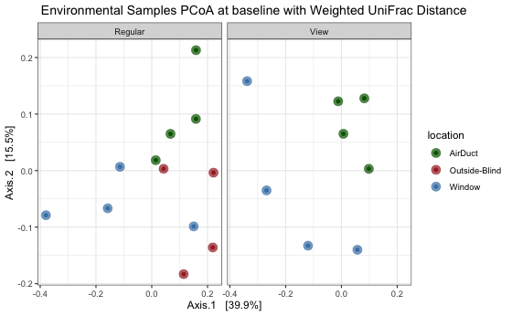

```r
Envir_T0_nb  <- subset_samples(Envir_T0_nb, sample_names(Envir_T0_nb) !='R4T0_AD') # This is an outlier
Envir_T0_nb.df=data.frame(sample_data(Envir_T0_nb))

Envir_T0_nb_wuf = phyloseq::distance(Envir_T0_nb, method="wunifrac")
ordination_Envir_T0_nb_wuf = ordinate(Envir_T0_nb, method="PCoA", distance=Envir_T0_nb_wuf)


plot_ordination(Envir_T0_nb, ordination_Envir_T0_nb_wuf, color="location",
                title=" Environmental Samples PCoA at baseline with Weighted UniFrac Distance") +
                facet_wrap(Room.Type~.)+
                scale_color_manual(values = Envir_colors)+
                #scale_shape_manual(values= c(15,16,17,10))+
                geom_point(aes(color=location),alpha=0.7,size=4)+
                theme_bw()
```

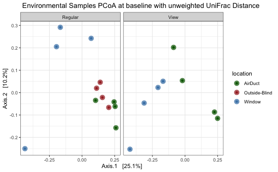

```r
Envir_T0_nb_unwuf = phyloseq::distance(Envir_T0_nb, method="uunifrac")
ordination_Envir_T0_nb_unwuf = ordinate(Envir_T0_nb, method="PCoA", distance=Envir_T0_nb_unwuf)

plot_ordination(Envir_T0_nb, ordination_Envir_T0_nb_unwuf, color="location",
                title=" Environmental Samples PCoA at baseline with unweighted UniFrac Distance") +
                facet_wrap(Room.Type~.)+
                scale_color_manual(values = Envir_colors_nb)+
                #scale_shape_manual(values= c(15,16,17,10))+
                geom_point(aes(color=location),alpha=0.7,size=4)+
                theme_bw()
```

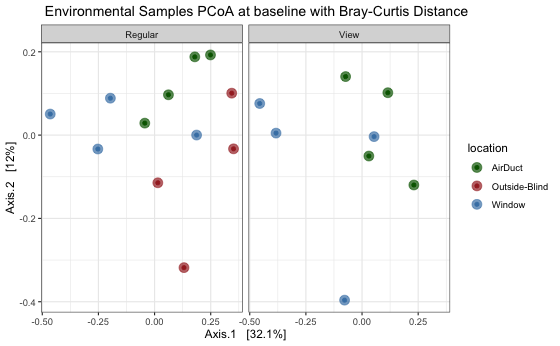

```r
Envir_T0_nb_bc= phyloseq::distance(Envir_T0_nb, method="bray")
ordination_Envir_T0_nb_bray = ordinate(Envir_T0_nb, method="PCoA", distance=Envir_T0_nb_bc)

plot_ordination(Envir_T0_nb, ordination_Envir_T0_nb_bray, color="location", #shape='Room.Type',
                title=" Environmental Samples PCoA at baseline with Bray-Curtis Distance") +
  facet_wrap(Room.Type~.)+
  scale_color_manual(values = Envir_colors)+
  #scale_shape_manual(values= c(15,16,17,10))+
  geom_point(aes(color=location),alpha=0.7,size=4)+
  theme_bw()
```

**T1**

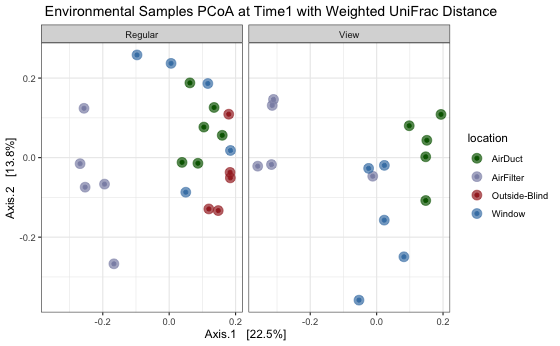

```r
Envir_T1_nb_wuf = phyloseq::distance(Envir_T1_nb, method="wunifrac")
ordination_Envir_T1_nb_wuf = ordinate(Envir_T1_nb, method="PCoA", distance=Envir_T1_nb_wuf)

Envir_T1_nb_wuf_pcoa<- plot_ordination(Envir_T1_nb, ordination_Envir_T1_nb_wuf, color="location",
                        title=" Environmental Samples PCoA at Time1 with Weighted UniFrac Distance") +
                        facet_wrap(Room.Type~.)+
                        scale_color_manual(values = Envir_colors_nb)+
                        #scale_shape_manual(values= c(15,16,17,10))+
                        geom_point(aes(color=location),alpha=0.7,size=4)+
                        theme_bw()

Envir_T1_nb_wuf_pcoa
```

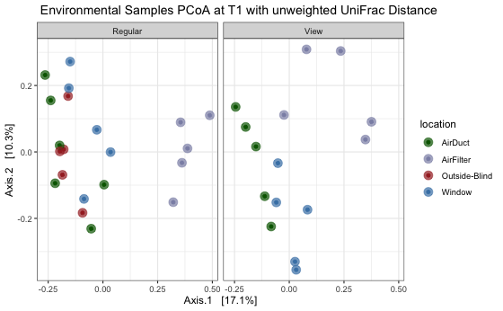

```r
Envir_T1_nb_unwuf = phyloseq::distance(Envir_T1_nb, method="uunifrac")
ordination_Envir_T1_nb_unwuf = ordinate(Envir_T1_nb, method="PCoA", distance=Envir_T1_nb_unwuf)

plot_ordination(Envir_T1_nb, ordination_Envir_T1_nb_unwuf, color="location",
                title=" Environmental Samples PCoA at T1 with unweighted UniFrac Distance") +
                facet_wrap(Room.Type~.)+
                scale_color_manual(values = Envir_colors_nb)+
                #scale_shape_manual(values= c(15,16,17,10))+
                geom_point(aes(color=location),alpha=0.7,size=4)+
                theme_bw()
```

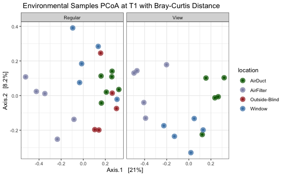

```r
Envir_T1_nb_bc= phyloseq::distance(Envir_T1_nb, method="bray")
ordination_Envir_T1_nb_bray = ordinate(Envir_T1_nb, method="PCoA", distance=Envir_T1_nb_bc)

plot_ordination(Envir_T1_nb, ordination_Envir_T1_nb_bray, color="location",
                title=" Environmental Samples PCoA at T1 with Bray-Curtis Distance") +
                facet_wrap(Room.Type~.)+
                scale_color_manual(values = Envir_colors)+
                #scale_shape_manual(values= c(15,16,17,10))+
                geom_point(aes(color=location),alpha=0.7,size=4)+
                theme_bw()
```

**T3**

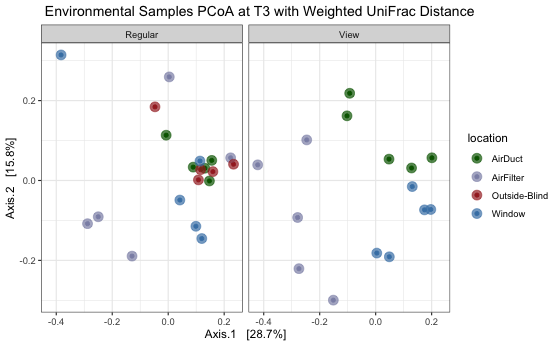

```r
Envir_T3_nb_wuf = phyloseq::distance(Envir_T3_nb, method="wunifrac")
ordination_Envir_T3_nb_wuf = ordinate(Envir_T3_nb, method="PCoA", distance=Envir_T3_nb_wuf)

plot_ordination(Envir_T3_nb, ordination_Envir_T3_nb_wuf, color="location",
                title=" Environmental Samples PCoA at T3 with Weighted UniFrac Distance") +
                facet_wrap(Room.Type~.)+
                scale_color_manual(values = Envir_colors_nb)+
                #scale_shape_manual(values= c(15,16,17,10))+
                geom_point(aes(color=location),alpha=0.7,size=4)+
                theme_bw()
```

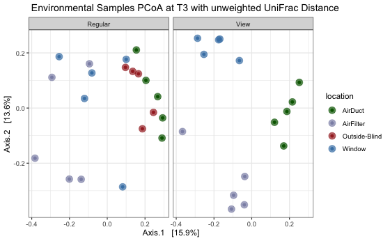

```r
Envir_T3_nb_unwuf = phyloseq::distance(Envir_T3_nb, method="uunifrac")
ordination_Envir_T3_nb_unwuf = ordinate(Envir_T3_nb, method="PCoA", distance=Envir_T3_nb_unwuf)

plot_ordination(Envir_T3_nb, ordination_Envir_T3_nb_unwuf, color="location",
                title=" Environmental Samples PCoA at T3 with unweighted UniFrac Distance") +
                facet_wrap(Room.Type~.)+
                scale_color_manual(values = Envir_colors_nb)+
                #scale_shape_manual(values= c(15,16,17,10))+
                geom_point(aes(color=location),alpha=0.7,size=4)+
                theme_bw()
```

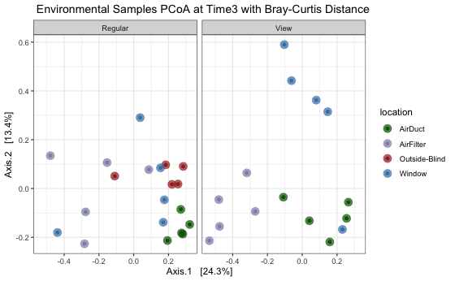

```r
Envir_T3_nb_bc= phyloseq::distance(Envir_T3_nb, method="bray")
ordination_Envir_T3_nb_bray = ordinate(Envir_T3_nb, method="PCoA", distance=Envir_T3_nb_bc)

plot_ordination(Envir_T3_nb, ordination_Envir_T3_nb_bray, color="location",
                title=" Environmental Samples PCoA at Time3 with Bray-Curtis Distance") +
                facet_wrap(Room.Type~.)+
                scale_color_manual(values = Envir_colors)+
                #scale_shape_manual(values= c(15,16,17,10))+
                geom_point(aes(color=location),alpha=0.7,size=4)+
                theme_bw()
```